# Homework 03

## Question 1: Build an `explain-to-me` skill

Create a small skill named `explain-to-me` that helps you understand a homework question.

1. Design your `SKILL.md` file so that, when you explicitly ask your agent to use the skill to read a homework question, the agent communicates with you and explains what the question is asking.
2. Keep the skill file short. It should contain a few useful rules, instructions, and a clear statement of your intent. For example, you may ask the agent to explain the goal of the question, clarify what work is required, and point you to an appropriate section of the Week 3 lectures: [Ridge Regression: Stability Through Shrinkage](https://teazrq.github.io/stat432rpy/topics/ridge-regression/ridge-regression.html) or [From a Penalized Objective to a Fitted Ridge Model](https://teazrq.github.io/stat432rpy/topics/ridge-regression/optimization-and-cross-validation.html). The skill should help you understand the question without completing the solution for you.
3. Create the skill yourself or with the help of AI. Save it as `explain-to-me/SKILL.md`. Then ask your AI agent to install the skill using its normal skill-installation method. Test it by explicitly asking the agent to use `explain-to-me` to read and explain Question 2.
4. If the skill does not work well, or if it begins to disturb your usual workflow, ask your agent to remove the installed skill. You may revise and reinstall it if you wish.
5. In all cases, append the complete contents of your developed `explain-to-me/SKILL.md` file at the end of your Homework 3 submission under the heading **`explain-to-me` skill**.

## Question 2: Ridge regression with nearly collinear predictors

Let $n=100$. Generate mutually independent standard normal random variables

$$L_i, U_{i1}, U_{i2}, X_{i3}, X_{i4},
\qquad i=1,\ldots,n,$$

and define

$$X_{i1}=L_i+0.04U_{i1},
\qquad
X_{i2}=L_i+0.04U_{i2}.$$

Center and standardize each column of $\mathbf X$ to have mean zero and average squared value one, following the [lecture’s scaling convention](https://teazrq.github.io/stat432rpy/topics/ridge-regression/ridge-regression.html#put-every-covariate-on-a-common-scale).

Continue to use $\mathbf X\in\mathbb R^{n\times p}$ for the standardized matrix and keep it fixed throughout the question, where $p=4$ is the number of predictors. The unpenalized intercept gives $p+1=5$ total fitted coefficients. Let

$$\boldsymbol\beta
=
(1.5,1.5,1,0)^{\mathsf T},
\qquad
\boldsymbol\mu
=
\mathbf X\boldsymbol\beta.$$

Generate a training response and an independent test response at the same predictor values:

$$\begin{aligned}
\mathbf y
&=
\boldsymbol\mu+\boldsymbol\epsilon,\\
\mathbf y^*
&=
\boldsymbol\mu+\boldsymbol\epsilon^*,
\end{aligned}$$

where

$$\boldsymbol\epsilon,
\boldsymbol\epsilon^*
\overset{\mathrm{ind}}{\sim}
\mathcal N_n(\mathbf0,\mathbf I_n).$$

Center the training response as $\widetilde{\mathbf y}=\mathbf y-\bar y\mathbf1_n$. For each $\lambda\in\{0,0.02,0.2\}$, fit the slopes using the lecture’s ridge formula:

$$\widehat{\boldsymbol\beta}_\lambda
=
\left(\mathbf X^{\mathsf T}\mathbf X+n\lambda\mathbf I_p\right)^{-1}
\mathbf X^{\mathsf T}\widetilde{\mathbf y}.$$

The unpenalized intercept is $\widehat\beta_0=\bar y$; add this training mean back when predicting either response. The case $\lambda=0$ is ordinary least squares. Use seed `43231` before generating the design and responses. R and Python use different random-number generators, so their exact numerical results need not agree.

1. Generate $\mathbf X$ once. Report the correlation between its first two columns and its largest and smallest singular values. Use these quantities to explain why the estimator contrast $\widehat\beta_1-\widehat\beta_2$ should be much more variable than $\widehat\beta_1+\widehat\beta_2$.

**Show the workflow**

```python
import pandas as pd
import numpy as np

n = 100
rng = np.random.default_rng(43231)
L = rng.normal(size=n)
U1 = rng.normal(size=n)
U2 = rng.normal(size=n)
X3 = rng.normal(size=n)
X4 = rng.normal(size=n)
X = np.column_stack((
    L + 0.04 * U1,
    L + 0.04 * U2,
    X3,
    X4
))
X = X - X.mean(axis=0)
X = X / np.sqrt(np.mean(X**2, axis=0))
s = np.linalg.svd(X, compute_uv=False)

print(f"Correlation between X1 and X2: {np.corrcoef(X[:, 0], X[:, 1])[0, 1]:.4f}")
print(f"Largest singular value: {s.max():.4f}")
print(f"Smallest singular value: {s.min():.4f}")
```

```
Correlation between X1 and X2: 0.9983
Largest singular value: 14.1730
Smallest singular value: 0.4061
```

The correlation between X1 and X2 is close to 1, which means X1 $\approx$ X2. Therefore, the largest singular value is likely to occur when t(X1 + X2), and the smallest singular value is likely to occur when t(X1 - X2). This means it will have similar effect when combine together. Therefore, the sum of beta1 and 2 is similar, but their difference is more variable bacause of the random noise.

2. Independently repeat the generation of $\mathbf y$ and $\mathbf y^*$, followed by all three fits, 200 times while keeping $\mathbf X$ fixed. Draw the training and test noise inside each repetition, then reuse that realized pair for all three values of $\lambda$. For each value of $\lambda$, report the empirical mean and standard deviation of

$$\widehat\beta_1,
\quad
\widehat\beta_2,
\quad
\widehat\beta_1+\widehat\beta_2,
\quad
\widehat\beta_1-\widehat\beta_2.$$

Also report the average training MSE and the average test MSE calculated from the independent test response, where

$$\operatorname{MSE}_{\mathrm{test}}
=
\frac{1}{n}
\left\lVert
\mathbf y^*
-
\widehat\beta_0\mathbf1_n
-
\mathbf X\widehat{\boldsymbol\beta}
\right\rVert_2^2.$$

**Show the workflow**

```python
lamda = np.array([0, 0.02, 0.2])
beta = np.array([1.5, 1.5, 1.0, 0.0])
mu = X @ beta
p = X.shape[1]

result = pd.DataFrame(
    np.nan,
    index=["lambda=0", "lambda=0.02", "lambda=0.2"],
    columns=["mean_beta1", "sd_beta1", "mean_beta2", "sd_beta2",
             "mean_beta_sum", "sd_beta_sum", "mean_beta_diff", "sd_beta_diff",
             "train_mse", "test_mse"]
)

train_responses = np.empty((200, n))
test_responses = np.empty((200, n))
for r in range(200):
    train_responses[r] = mu + rng.normal(size=n)
    test_responses[r] = mu + rng.normal(size=n)

for l in range(len(lamda)):
    y_train = pd.DataFrame(
        np.nan,
        index=range(200),
        columns=["beta1", "beta2", "beta_sum", "beta_diff", "train_mse", "test_mse"]
    )

    for r in y_train.index:
        yr_train = train_responses[r]
        yr_test = test_responses[r]
        beta0_hat = yr_train.mean()
        yr_tilde = yr_train - beta0_hat
        beta_hat = np.linalg.inv(X.T @ X + n * lamda[l] * np.eye(p)) @ X.T @ yr_tilde
        beta_sum = beta_hat[0] + beta_hat[1]
        beta_diff = beta_hat[0] - beta_hat[1]
        y_hat = beta0_hat + X @ beta_hat
        mse_train = np.mean((yr_train - y_hat)**2)
        mse_test = np.mean((yr_test - y_hat)**2)
        y_train.loc[r] = [
            beta_hat[0], beta_hat[1], beta_sum, beta_diff, mse_train, mse_test
        ]

    result.iloc[l] = [
        y_train["beta1"].mean(),
        y_train["beta1"].std(),
        y_train["beta2"].mean(),
        y_train["beta2"].std(),
        y_train["beta_sum"].mean(),
        y_train["beta_sum"].std(),
        y_train["beta_diff"].mean(),
        y_train["beta_diff"].std(),
        y_train["train_mse"].mean(),
        y_train["test_mse"].mean(),
    ]

result
```

|  | mean_beta1 | sd_beta1 | mean_beta2 | sd_beta2 | mean_beta_sum | sd_beta_sum | mean_beta_diff | sd_beta_diff | train_mse | test_mse |
| --- | --- | --- | --- | --- | --- | --- | --- | --- | --- | --- |
| lambda=0 | 1.290103 | 1.795135 | 1.701421 | 1.797916 | 2.991524 | 0.104908 | -0.411319 | 3.591520 | 0.949265 | 1.038398 |
| lambda=0.02 | 1.464518 | 0.144652 | 1.496776 | 0.147926 | 2.961294 | 0.103896 | -0.032258 | 0.273530 | 0.959724 | 1.029182 |
| lambda=0.2 | 1.355268 | 0.049432 | 1.359321 | 0.050405 | 2.714589 | 0.095437 | -0.004054 | 0.029327 | 1.063901 | 1.125260 |

3. Interpret the coefficient estimates and test MSE using bias and variance. Explain why ridge can substantially stabilize the individual coefficients without producing an equally large change in the fitted values.

## Question 3: What does ridge regression shrink?

Let $\mathbf X\in\mathbb R^{n\times p}$ be a centered predictor matrix, and let $\widetilde{\mathbf y}\in\mathbb R^n$ be the centered response. Use the supplied predictor scales for this algebraic question; the columns need not have unit variance. Here $p$ counts predictors, $\boldsymbol\beta\in\mathbb R^p$ contains their slopes, and $p+1$ counts all fitted coefficients, including the separately fitted, unpenalized intercept. Ridge regression minimizes

$$L_\lambda(\boldsymbol\beta)
=
\frac{1}{2n}
\left\lVert
\widetilde{\mathbf y}-\mathbf X\boldsymbol\beta
\right\rVert_2^2
+
\frac{\lambda}{2}
\lVert\boldsymbol\beta\rVert_2^2.$$

1. Derive the ridge normal equation

$$\left(
\mathbf X^{\mathsf T}\mathbf X
+n\lambda\mathbf I_p
\right)
\widehat{\boldsymbol\beta}_\lambda
=
\mathbf X^{\mathsf T}\widetilde{\mathbf y}.$$

Explain why it has a unique solution whenever $\lambda>0$, even if $\mathbf X$ is rank deficient or $p>n$.

$$\begin{aligned}
L_\lambda(\boldsymbol\beta)
&= \frac{1}{2n}\left\lVert\widetilde{\mathbf y}-\mathbf X\boldsymbol\beta\right\rVert_2^2
+\frac{\lambda}{2}\lVert\boldsymbol\beta\rVert_2^2 \\
&= \frac{1}{2n}(\widetilde{\mathbf y}-\mathbf X\boldsymbol\beta)^{\mathsf T}
(\widetilde{\mathbf y}-\mathbf X\boldsymbol\beta)
+\frac{\lambda}{2}\boldsymbol\beta^{\mathsf T}\boldsymbol\beta \\
&= \frac{1}{2n}(\widetilde{\mathbf y}^{\mathsf T}-\boldsymbol\beta^{\mathsf T}\mathbf X^{\mathsf T})
(\widetilde{\mathbf y}-\mathbf X\boldsymbol\beta)
+\frac{\lambda}{2}\boldsymbol\beta^{\mathsf T}\boldsymbol\beta \\
&= \frac{1}{2n}\left(
\widetilde{\mathbf y}^{\mathsf T}\widetilde{\mathbf y}
-2\boldsymbol\beta^{\mathsf T}\mathbf X^{\mathsf T}\widetilde{\mathbf y}
+\boldsymbol\beta^{\mathsf T}\mathbf X^{\mathsf T}\mathbf X\boldsymbol\beta
\right)+\frac{\lambda}{2}\boldsymbol\beta^{\mathsf T}\boldsymbol\beta.
\end{aligned}$$

$$\begin{aligned}
\nabla_{\boldsymbol\beta}L_\lambda(\boldsymbol\beta)
&= \nabla_{\boldsymbol\beta}\left[
\frac{1}{2n}\left(
\widetilde{\mathbf y}^{\mathsf T}\widetilde{\mathbf y}
-2\boldsymbol\beta^{\mathsf T}\mathbf X^{\mathsf T}\widetilde{\mathbf y}
+\boldsymbol\beta^{\mathsf T}\mathbf X^{\mathsf T}\mathbf X\boldsymbol\beta
\right)+\frac{\lambda}{2}\boldsymbol\beta^{\mathsf T}\boldsymbol\beta
\right] \\
&= \frac{1}{2n}\left(
-2\mathbf X^{\mathsf T}\widetilde{\mathbf y}
+2\mathbf X^{\mathsf T}\mathbf X\boldsymbol\beta
\right)+\lambda\boldsymbol\beta.
\end{aligned}$$

$$\begin{aligned}
\mathbf 0
&= \frac{1}{2n}\left(
-2\mathbf X^{\mathsf T}\widetilde{\mathbf y}
+2\mathbf X^{\mathsf T}\mathbf X\widehat{\boldsymbol\beta}_\lambda
\right)+\lambda\widehat{\boldsymbol\beta}_\lambda \\
\mathbf 0
&= -\mathbf X^{\mathsf T}\widetilde{\mathbf y}
+\mathbf X^{\mathsf T}\mathbf X\widehat{\boldsymbol\beta}_\lambda
+n\lambda\widehat{\boldsymbol\beta}_\lambda \\
\mathbf X^{\mathsf T}\widetilde{\mathbf y}
&= \left(\mathbf X^{\mathsf T}\mathbf X+n\lambda\mathbf I_p\right)
\widehat{\boldsymbol\beta}_\lambda.
\end{aligned}$$

For every nonzero vector $\mathbf a\in\mathbb R^p$,

$$\begin{aligned}
\mathbf a^{\mathsf T}
\left(
\mathbf X^{\mathsf T}\mathbf X+n\lambda\mathbf I_p
\right)\mathbf a
&=
\mathbf a^{\mathsf T}\mathbf X^{\mathsf T}\mathbf X\mathbf a
+n\lambda\mathbf a^{\mathsf T}\mathbf a\\
&=
\lVert\mathbf X\mathbf a\rVert_2^2
+n\lambda\lVert\mathbf a\rVert_2^2\\
&>0
\end{aligned}$$

when $\lambda>0$. Therefore, $\mathbf X^{\mathsf T}\mathbf X+n\lambda\mathbf I_p$ is positive definite and hence invertible. Thus, the ridge normal equation has a unique solution even if $\mathbf X$ is rank deficient or $p>n$.

2. Let

$$\mathbf X
=
\mathbf U_r\mathbf D_r\mathbf V_r^{\mathsf T}$$

be a compact singular value decomposition, where $r=\operatorname{rank}(\mathbf X)$, $\mathbf U_r\in\mathbb R^{n\times r}$, $\mathbf D_r\in\mathbb R^{r\times r}$, and $\mathbf V_r\in\mathbb R^{p\times r}$. Show that ridge multiplies the fitted response component in the $j$th left singular-vector direction, for $j=1,\ldots,r$, by

$$\rho_j(\lambda)
=
\frac{d_j^2}{d_j^2+n\lambda}.$$

Suppose $n=100$, $\lambda=0.01$, and the nonzero singular values are

$$d_1=10,
\qquad
d_2=2,
\qquad
d_3=0.2.$$

Calculate the three shrinkage factors and the total effective degrees of freedom, including the unpenalized intercept:

$$\operatorname{df}_{\mathrm{eff}}(\lambda)
=
1+\sum_{j=1}^3\rho_j(\lambda).$$

Starting from the ridge fitted response and substituting the compact SVD,

$$\begin{aligned}
\widehat{\widetilde{\mathbf y}}_\lambda
&= \mathbf X\widehat{\boldsymbol\beta}_\lambda \\
&= \mathbf X
\left(\mathbf X^{\mathsf T}\mathbf X+n\lambda\mathbf I_p\right)^{-1}
\mathbf X^{\mathsf T}\widetilde{\mathbf y} \\
&= \mathbf U_r\mathbf D_r\mathbf V_r^{\mathsf T}\mathbf V_r
\left(\mathbf D_r^2+n\lambda\mathbf I_r\right)^{-1}
\mathbf D_r\mathbf U_r^{\mathsf T}\widetilde{\mathbf y} \\
&= \mathbf U_r\mathbf D_r
\left(\mathbf D_r^2+n\lambda\mathbf I_r\right)^{-1}
\mathbf D_r\mathbf U_r^{\mathsf T}\widetilde{\mathbf y},
\end{aligned}$$
because $\mathbf V_r^{\mathsf T}\mathbf V_r=\mathbf I_r$.

Since

$$\mathbf D_r
=
\operatorname{diag}(d_1,\ldots,d_r),$$

we have

$$\begin{aligned}
\mathbf R_\lambda
&=
\mathbf D_r
\left(\mathbf D_r^2+n\lambda\mathbf I_r\right)^{-1}
\mathbf D_r \\
&=
\operatorname{diag}\left(
\frac{d_1^2}{d_1^2+n\lambda},\ldots,
\frac{d_r^2}{d_r^2+n\lambda}
\right).
\end{aligned}$$

Therefore, the $j$th diagonal element of $\mathbf R_\lambda$ is

$$\rho_j(\lambda)
=
\frac{d_j^2}{d_j^2+n\lambda}.$$

Also,

$$\mathbf U_r^{\mathsf T}\widetilde{\mathbf y}
=
\begin{pmatrix}
\mathbf u_1^{\mathsf T}\widetilde{\mathbf y}\\
\vdots\\
\mathbf u_r^{\mathsf T}\widetilde{\mathbf y}
\end{pmatrix},$$

so multiplying by $\mathbf R_\lambda$ gives

$$\mathbf R_\lambda\mathbf U_r^{\mathsf T}\widetilde{\mathbf y}
=
\begin{pmatrix}
\rho_1(\lambda)\left(\mathbf u_1^{\mathsf T}\widetilde{\mathbf y}\right)\\
\vdots\\
\rho_r(\lambda)\left(\mathbf u_r^{\mathsf T}\widetilde{\mathbf y}\right)
\end{pmatrix}.$$

Thus,

$$\widehat{\widetilde{\mathbf y}}_\lambda
=
\sum_{j=1}^r
\rho_j(\lambda)
\left(\mathbf u_j^{\mathsf T}\widetilde{\mathbf y}\right)\mathbf u_j.$$

Here $\mathbf u_j^{\mathsf T}\widetilde{\mathbf y}$ is the amount of the response in direction $\mathbf u_j$, and $\rho_j(\lambda)$ is the proportion of that component retained by ridge. In comparison, the OLS fitted response is

$$\widehat{\widetilde{\mathbf y}}_{\mathrm{OLS}}
=
\sum_{j=1}^r
\left(\mathbf u_j^{\mathsf T}\widetilde{\mathbf y}\right)\mathbf u_j.$$

For $n=100$ and $\lambda=0.01$, the three shrinkage factors are

$$\begin{aligned}
\rho_1
&= \frac{10^2}{10^2+100(0.01)}
\approx 0.99, \\
\rho_2
&= \frac{2^2}{2^2+100(0.01)}
= 0.8, \\
\rho_3
&= \frac{0.2^2}{0.2^2+100(0.01)}
\approx 0.038.
\end{aligned}$$

Therefore, including the unpenalized intercept, the total effective degrees of freedom are

$$\operatorname{df}_{\mathrm{eff}}(\lambda)
= 1+0.99+0.8+0.038
= 2.828.$$

3. Which direction receives the strongest shrinkage? Explain why shrinking this direction can reduce prediction variance. Under what circumstance could the same shrinkage produce substantial prediction bias?

The third direction receives the strongest shrinkage. When singular value is small, random noise in the amout of response in direction $u_j$ is amplified. Then, ridge gives these direction a stronger shrinkage leading to the reduction in prediction variance. Ridge’s bias in direction $u_j$ depends on $(1 - p_j)(u_j^{\mathsf T}\mu)$. Therefore, large bias will be introduced when there are large amount of genuine signal in this direction.

## Question 4: Ridge regression and optimization

Let $\mathbf X\in\mathbb R^{n\times p}$ be a centered predictor matrix with $p=2$. Its columns need not have unit variance in this question. The intercept is fitted separately and is not penalized. Suppose the two eigenvalues of

$$\mathbf A_0
=
\frac{1}{n}\mathbf X^{\mathsf T}\mathbf X$$

are $9$ and $0.01$. Ridge regression with $\lambda=0.09$ has curvature matrix

$$\mathbf A_\lambda
=
\frac{1}{n}\mathbf X^{\mathsf T}\mathbf X
+
\lambda\mathbf I_p.$$

1. Calculate the condition numbers of $\mathbf A_0$ and $\mathbf A_\lambda$. Explain what the change says about the geometry of the ridge objective.

The condition number of $\mathbf A_0$ is 900. The conditional number of $\mathbf A_\lambda$ is 90.9. It especially increases curvature in the formerly flat direction, making the optimization problem more stable.

2. Gradient descent uses

$$\boldsymbol\beta^{(k+1)}
=
\boldsymbol\beta^{(k)}
-
\eta\nabla L_\lambda\!\left(\boldsymbol\beta^{(k)}\right).$$

Let $\widehat{\boldsymbol\beta}_\lambda$ be the ridge minimizer and define the optimization error

$$\mathbf e^{(k)}
=
\boldsymbol\beta^{(k)}
-
\widehat{\boldsymbol\beta}_\lambda.$$

Show that the component of $\mathbf e^{(k)}$ in an eigendirection with unpenalized eigenvalue $a$ is multiplied at each step by

$$1-\eta(a+\lambda).$$

Let $M=9.09$, the largest eigenvalue of $\mathbf A_\lambda$. Find the interval of step sizes that contracts every eigendirection. Then compare these two choices:

- For $\eta=1/M$, calculate the two contraction factors and explain which direction converges faster.
- For $\eta=2.1/M$, determine whether the method converges. Assume the initial error has a nonzero component in the eigendirection corresponding to $M$.

$$\nabla L_\lambda(\boldsymbol\beta)
=
\mathbf A_\lambda\boldsymbol\beta-\mathbf b,
\qquad
\mathbf A_\lambda
=
\frac{1}{n}\mathbf X^{\mathsf T}\mathbf X+\lambda\mathbf I.$$

For the minimizer,

$$\begin{aligned}
\nabla L_\lambda(\widehat{\boldsymbol\beta}_\lambda)&=0,\\
\mathbf A_\lambda\widehat{\boldsymbol\beta}_\lambda-\mathbf b&=0,\\
\mathbf b&=\mathbf A_\lambda\widehat{\boldsymbol\beta}_\lambda.
\end{aligned}$$

Also,

$$\mathbf e^{(k)}
=
\boldsymbol\beta^{(k)}-\widehat{\boldsymbol\beta}_\lambda.$$

Therefore,

$$\begin{aligned}
\mathbf e^{(k+1)}
&=\boldsymbol\beta^{(k+1)}-\widehat{\boldsymbol\beta}_\lambda\\
&=\boldsymbol\beta^{(k)}
-\eta\nabla L_\lambda(\boldsymbol\beta^{(k)})
-\widehat{\boldsymbol\beta}_\lambda\\
&=\boldsymbol\beta^{(k)}
-\eta\left(\mathbf A_\lambda\boldsymbol\beta^{(k)}-\mathbf b\right)
-\widehat{\boldsymbol\beta}_\lambda\\
&=\left(\mathbf I-\eta\mathbf A_\lambda\right)\boldsymbol\beta^{(k)}
+\eta\mathbf b-\widehat{\boldsymbol\beta}_\lambda\\
&=\left(\mathbf I-\eta\mathbf A_\lambda\right)\boldsymbol\beta^{(k)}
+\eta\mathbf A_\lambda\widehat{\boldsymbol\beta}_\lambda
-\widehat{\boldsymbol\beta}_\lambda\\
&=\left(\mathbf I-\eta\mathbf A_\lambda\right)\boldsymbol\beta^{(k)}
-\left(\mathbf I-\eta\mathbf A_\lambda\right)\widehat{\boldsymbol\beta}_\lambda\\
&=\left(\mathbf I-\eta\mathbf A_\lambda\right)\mathbf e^{(k)}.
\end{aligned}$$

Suppose $\mathbf q$ is an eigenvector of $\mathbf A_0$ with eigenvalue $a$:

$$\mathbf A_0\mathbf q=a\mathbf q.$$

Since $\mathbf A_\lambda=\mathbf A_0+\lambda\mathbf I$,

$$\mathbf A_\lambda\mathbf q=(a+\lambda)\mathbf q.$$

If the error has component $c_k\mathbf q$, the next component is

$$c_{k+1}\mathbf q
=
\left[1-\eta(a+\lambda)\right]c_k\mathbf q.$$

It contracts when

$$\left|1-\eta(a+\lambda)\right|<1
\quad\Longrightarrow\quad
|1-\eta M|<1
\quad\Longrightarrow\quad
0<\eta<\frac{2}{M}
\quad\Longrightarrow\quad
0<\eta<0.2200.$$

When $\eta=1/M$,

$$a+\lambda=9.09\text{ or }0.1.$$

The contraction factors are

$$1-\frac{9.09}{9.09}=0$$

and

$$1-\frac{0.1}{9.09}=0.99.$$

The contraction factor for eigenvalue $9.09$ is closer to $0$, which means this direction contracts faster.

When $\eta=2.1/M$,

$$1-\frac{2.1}{M}M
=
1-2.1
=
-1.1.$$

Since

$$|-1.1|>1,$$

it will not converge.

3. Increasing $\lambda$ generally improves the condition number. Explain why choosing $\lambda$ to make gradient descent converge as quickly as possible is not a valid statistical tuning rule.

The penalty $\lambda$ defines the statistical estimator, so increasing it changes the model rather than merely making the same computation faster. A larger $\lambda$ can improve conditioning and reduce variance, but it also introduces more shrinkage bias and may worsen prediction. Therefore, $\lambda$ should be chosen using a statistical prediction criterion such as cross-validation or GCV. The step size and optimization algorithm should be chosen separately to solve the selected objective accurately.

## Question 5: Selecting the ridge penalty for real-estate prediction

The supplied `data/realestate.csv` contains 414 real-estate transactions from Sindian District, New Taipei City, Taiwan. The quantitative response `price` is the unit house price. The six predictors are the transaction date, house age, distance to the nearest mass rapid transit station, number of nearby convenience stores, latitude, and longitude. Treat all six predictors as quantitative in this question. The column `row_id` identifies an observation and must not be used as a predictor.

The file `data/realestate-split-folds.csv` assigns 332 observations to the training set and 82 observations to the final test set. It also gives ten fold labels for the training observations. Match the two files using `row_id` and do not use the test responses while selecting a model.

Use the penalty grid

$$\Lambda
=
\{0\}
\mathbin{\cup}
\left\{
10^{-4+0.05l}:l=0,\ldots,120
\right\}.$$

For every fit, center and standardize each predictor using only the observations available to that fit, with the variance divided by the number of fitting observations. Center the response and leave the intercept unpenalized.

1. Perform ten-fold cross-validation over $\Lambda$ using the supplied training folds. Estimate the predictor means and scales separately within each set of nine training folds. For each $\lambda$, calculate the mean validation MSE and $\operatorname{SE}(\lambda)$, the sample standard deviation of the ten fold errors divided by $\sqrt{10}$. Use this SE for the conventional one-standard-error heuristic. Plot the mean validation MSE and identify $\lambda_{\min}$. Choose $\lambda_{\mathrm{1se}}$ as the largest candidate in $\Lambda$, including OLS, satisfying

$$\overline{\operatorname{MSE}}(\lambda)
\leq
\overline{\operatorname{MSE}}(\lambda_{\min})
+
\operatorname{SE}(\lambda_{\min}).$$

**Show the workflow**

```
lambda_min: 0.0199526
lambda_1se: 1.58489
Minimum mean validation MSE: 82.9776
One-SE cutoff: 102.2076
```

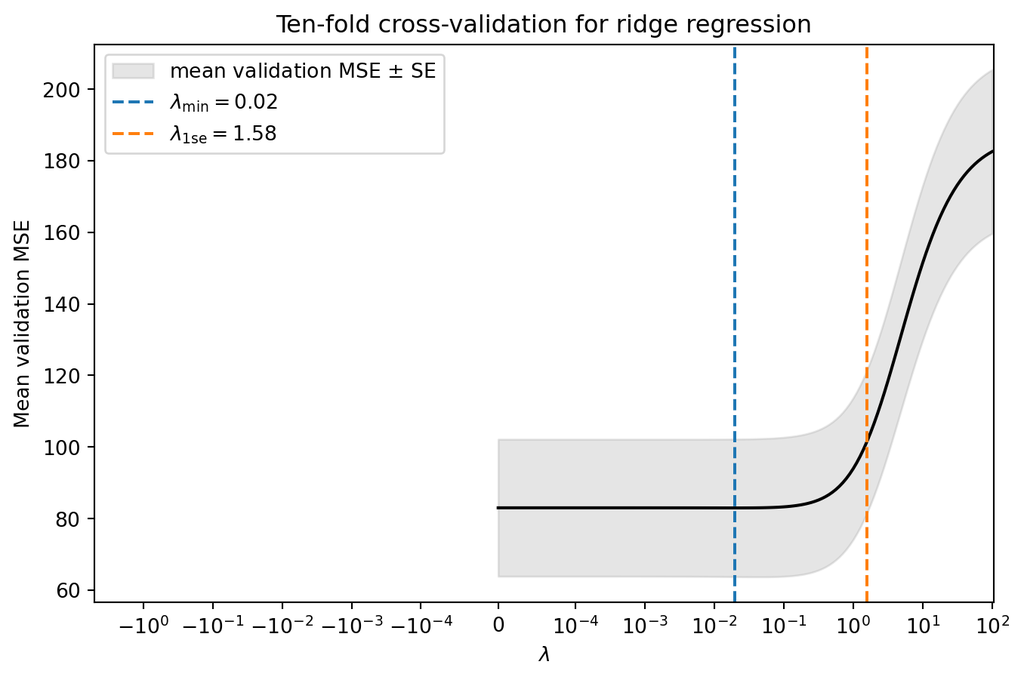

|  | lambda | mean_validation_mse | se |
| --- | --- | --- | --- |
| 0 | 0.000000 | 83.012387 | 19.145987 |
| 1 | 0.000100 | 83.012002 | 19.146463 |
| 2 | 0.000112 | 83.011956 | 19.146521 |
| 3 | 0.000126 | 83.011903 | 19.146586 |
| 4 | 0.000141 | 83.011845 | 19.146659 |
| ... | ... | ... | ... |
| 117 | 63.095734 | 179.891934 | 22.779764 |
| 118 | 70.794578 | 180.665038 | 22.813025 |
| 119 | 79.432823 | 181.362391 | 22.843095 |
| 120 | 89.125094 | 181.990621 | 22.870240 |
| 121 | 100.000000 | 182.555941 | 22.894712 |

122 rows × 3 columns

```python
import numpy as np
import pandas as pd
import matplotlib.pyplot as plt

# Match the observations to their supplied train/test split and CV folds.
realestate = pd.read_csv("data/realestate.csv")
split_folds = pd.read_csv("data/realestate-split-folds.csv")
realestate = realestate.merge(
    split_folds,
    on="row_id",
    how="inner",
    validate="one_to_one"
)

predictors = [
    "date", "age", "distance", "stores", "latitude", "longitude"
]
train = realestate.loc[realestate["split"] == "train"].copy()
folds = np.sort(train["cv_fold"].unique())

# The grid is sorted from the OLS fit (lambda = 0) to the largest penalty.
lambda_grid = np.concatenate((
    np.array([0.0]),
    10 ** (-4 + 0.05 * np.arange(121))
))

# Each row stores the validation MSEs from one supplied fold.
fold_mse = np.empty((len(folds), len(lambda_grid)))

for fold_index, fold in enumerate(folds):
    fit_data = train.loc[train["cv_fold"] != fold]
    validation_data = train.loc[train["cv_fold"] == fold]

    X_fit_raw = fit_data[predictors].to_numpy()
    X_validation_raw = validation_data[predictors].to_numpy()
    y_fit = fit_data["price"].to_numpy()
    y_validation = validation_data["price"].to_numpy()

    # Estimate all preprocessing quantities from the nine fitting folds only.
    X_mean = X_fit_raw.mean(axis=0)
    X_scale = np.sqrt(np.mean((X_fit_raw - X_mean) ** 2, axis=0))
    X_fit = (X_fit_raw - X_mean) / X_scale
    X_validation = (X_validation_raw - X_mean) / X_scale

    y_mean = y_fit.mean()
    y_fit_centered = y_fit - y_mean

    n_fit, p = X_fit.shape
    XtX = X_fit.T @ X_fit
    Xty = X_fit.T @ y_fit_centered

    for lambda_index, lambda_value in enumerate(lambda_grid):
        beta_hat = np.linalg.solve(
            XtX + n_fit * lambda_value * np.eye(p),
            Xty
        )
        y_validation_hat = y_mean + X_validation @ beta_hat
        fold_mse[fold_index, lambda_index] = np.mean(
            (y_validation - y_validation_hat) ** 2
        )

# Summarize the ten fold-level validation errors.
mean_validation_mse = fold_mse.mean(axis=0)
validation_se = fold_mse.std(axis=0, ddof=1) / np.sqrt(len(folds))

min_index = np.argmin(mean_validation_mse)
lambda_min = lambda_grid[min_index]
one_se_cutoff = (
    mean_validation_mse[min_index] + validation_se[min_index]
)

# Because lambda_grid is increasing, the last eligible value is lambda_1se.
eligible = np.flatnonzero(mean_validation_mse <= one_se_cutoff)
one_se_index = eligible[-1]
lambda_1se = lambda_grid[one_se_index]

cv_results = pd.DataFrame({
    "lambda": lambda_grid,
    "mean_validation_mse": mean_validation_mse,
    "se": validation_se
})

print(f"lambda_min: {lambda_min:.6g}")
print(f"lambda_1se: {lambda_1se:.6g}")
print(f"Minimum mean validation MSE: {mean_validation_mse[min_index]:.4f}")
print(f"One-SE cutoff: {one_se_cutoff:.4f}")

fig, ax = plt.subplots(figsize=(8, 5))
ax.plot(lambda_grid, mean_validation_mse, color="black")
ax.fill_between(
    lambda_grid,
    mean_validation_mse - validation_se,
    mean_validation_mse + validation_se,
    color="gray",
    alpha=0.2,
    label="mean validation MSE $\\pm$ SE"
)
ax.axvline(lambda_min, color="tab:blue", linestyle="--",
           label=rf"$\lambda_{{\min}}={lambda_min:.3g}$")
ax.axvline(lambda_1se, color="tab:orange", linestyle="--",
           label=rf"$\lambda_{{\mathrm{{1se}}}}={lambda_1se:.3g}$")
ax.set_xscale("symlog", linthresh=1e-4)
ax.set_xlabel(r"$\lambda$")
ax.set_ylabel("Mean validation MSE")
ax.set_title("Ten-fold cross-validation for ridge regression")
ax.legend()
plt.show()

cv_results
```

2. Use all $n=332$ training observations to calculate the [lecture’s GCV criterion](https://teazrq.github.io/stat432rpy/topics/ridge-regression/optimization-and-cross-validation.html#loocv-and-gcv) for each $\lambda\in\Lambda$:

$$\operatorname{GCV}(\lambda)
=
\frac{
\operatorname{MSE}_{\mathrm{train}}(\lambda)
}{
\left\{
1-\operatorname{df}_{\mathrm{eff}}(\lambda)/n
\right\}^2
}.$$

Here $\operatorname{MSE}_{\mathrm{train}}$ is the training MSE, and $\operatorname{df}_{\mathrm{eff}}$ includes the unpenalized intercept, as in Question 3. Estimate means and scales once from all training observations and keep them fixed for this calculation. Plot the GCV curve and identify $\lambda_{\mathrm{GCV}}$.

**Show the workflow**

```
lambda_GCV: 0.0281838
Minimum GCV: 83.5019
```

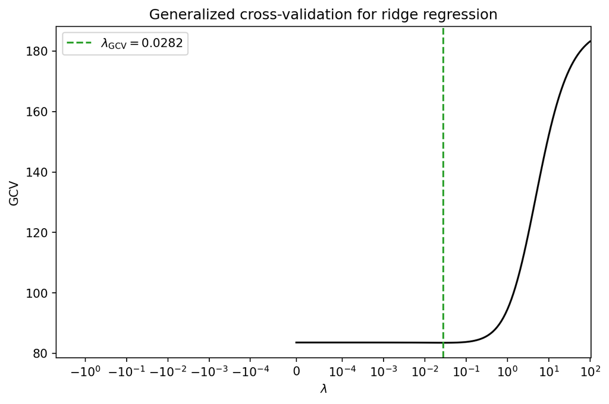

|  | lambda | training_mse | effective_df | gcv |
| --- | --- | --- | --- | --- |
| 0 | 0.000000 | 80.093917 | 7.000000 | 83.581273 |
| 1 | 0.000100 | 80.093919 | 6.998774 | 83.580644 |
| 2 | 0.000112 | 80.093919 | 6.998625 | 83.580567 |
| 3 | 0.000126 | 80.093919 | 6.998457 | 83.580481 |
| 4 | 0.000141 | 80.093920 | 6.998269 | 83.580385 |
| ... | ... | ... | ... | ... |
| 117 | 63.095734 | 179.352558 | 1.092718 | 180.539026 |
| 118 | 70.794578 | 180.130352 | 1.082859 | 181.311161 |
| 119 | 79.432823 | 180.831935 | 1.074027 | 182.007627 |
| 120 | 89.125094 | 181.463978 | 1.066119 | 182.635050 |
| 121 | 100.000000 | 182.032727 | 1.059043 | 183.199636 |

122 rows × 4 columns

```python
# Estimate the predictor means and scales once from all training observations.
X_train_raw = train[predictors].to_numpy()
y_train = train["price"].to_numpy()

X_train_mean = X_train_raw.mean(axis=0)
X_train_scale = np.sqrt(
    np.mean((X_train_raw - X_train_mean) ** 2, axis=0)
)
X_train = (X_train_raw - X_train_mean) / X_train_scale

y_train_mean = y_train.mean()
y_train_centered = y_train - y_train_mean

n_train, p = X_train.shape
XtX_train = X_train.T @ X_train
Xty_train = X_train.T @ y_train_centered
singular_values = np.linalg.svd(X_train, compute_uv=False)

training_mse = np.empty(len(lambda_grid))
effective_df = np.empty(len(lambda_grid))
gcv = np.empty(len(lambda_grid))

for lambda_index, lambda_value in enumerate(lambda_grid):
    beta_hat = np.linalg.solve(
        XtX_train + n_train * lambda_value * np.eye(p),
        Xty_train
    )
    y_train_hat = y_train_mean + X_train @ beta_hat
    training_mse[lambda_index] = np.mean((y_train - y_train_hat) ** 2)

    # Add one degree of freedom for the separately fitted intercept.
    shrinkage_factors = singular_values ** 2 / (
        singular_values ** 2 + n_train * lambda_value
    )
    effective_df[lambda_index] = 1 + shrinkage_factors.sum()
    gcv[lambda_index] = training_mse[lambda_index] / (
        1 - effective_df[lambda_index] / n_train
    ) ** 2

gcv_index = np.argmin(gcv)
lambda_gcv = lambda_grid[gcv_index]

gcv_results = pd.DataFrame({
    "lambda": lambda_grid,
    "training_mse": training_mse,
    "effective_df": effective_df,
    "gcv": gcv
})

print(f"lambda_GCV: {lambda_gcv:.6g}")
print(f"Minimum GCV: {gcv[gcv_index]:.4f}")

fig, ax = plt.subplots(figsize=(8, 5))
ax.plot(lambda_grid, gcv, color="black")
ax.axvline(
    lambda_gcv,
    color="tab:green",
    linestyle="--",
    label=rf"$\lambda_{{\mathrm{{GCV}}}}={lambda_gcv:.3g}$"
)
ax.set_xscale("symlog", linthresh=1e-4)
ax.set_xlabel(r"$\lambda$")
ax.set_ylabel("GCV")
ax.set_title("Generalized cross-validation for ridge regression")
ax.legend()
plt.show()

gcv_results
```

3. Fix all three choices before examining the test responses. Refit OLS and ridge at $\lambda_{\min}$, $\lambda_{\mathrm{1se}}$, and $\lambda_{\mathrm{GCV}}$ using all training observations. Report each model’s training MSE, test MSE, and effective degrees of freedom. Interpret the differences and explain why the model with the smallest observed test MSE must not be selected after viewing this table.

**Show the workflow**

```python
# All tuning choices have now been fixed without using the test responses.
selected_lambdas = {
    "OLS": 0.0,
    "ridge at lambda_min": lambda_min,
    "ridge at lambda_1se": lambda_1se,
    "ridge at lambda_GCV": lambda_gcv
}

# Examine the test responses only after fixing the choices above.
test = realestate.loc[realestate["split"] == "test"].copy()
X_test_raw = test[predictors].to_numpy()
y_test = test["price"].to_numpy()

# Apply the means and scales estimated from all training observations.
X_test = (X_test_raw - X_train_mean) / X_train_scale

model_results = []

for model_name, lambda_value in selected_lambdas.items():
    beta_hat = np.linalg.solve(
        XtX_train + n_train * lambda_value * np.eye(p),
        Xty_train
    )

    y_train_hat = y_train_mean + X_train @ beta_hat
    y_test_hat = y_train_mean + X_test @ beta_hat

    model_train_mse = np.mean((y_train - y_train_hat) ** 2)
    model_test_mse = np.mean((y_test - y_test_hat) ** 2)
    model_effective_df = 1 + np.sum(
        singular_values ** 2 /
        (singular_values ** 2 + n_train * lambda_value)
    )

    model_results.append({
        "model": model_name,
        "lambda": lambda_value,
        "training_mse": model_train_mse,
        "test_mse": model_test_mse,
        "effective_df": model_effective_df
    })

model_results = pd.DataFrame(model_results)
model_results.round({
    "lambda": 6,
    "training_mse": 4,
    "test_mse": 4,
    "effective_df": 4
})
```

|  | model | lambda | training_mse | test_mse | effective_df |
| --- | --- | --- | --- | --- | --- |
| 0 | OLS | 0.000000 | 80.0939 | 66.3225 | 7.0000 |
| 1 | ridge at lambda_min | 0.019953 | 80.1354 | 65.9996 | 6.7732 |
| 2 | ridge at lambda_1se | 1.584893 | 100.3736 | 81.1998 | 3.0329 |
| 3 | ridge at lambda_GCV | 0.028184 | 80.1713 | 65.9028 | 6.6887 |

OLS has the smallest training MSE, as expected, because it minimizes the unpenalized training sum of squared errors. The minimum-CV and GCV choices use mild shrinkage, retain effective degrees of freedom close to seven, and have similar training and test errors. The one-standard-error choice applies much stronger shrinkage, reduces the effective degrees of freedom to about three, and has larger training and test MSE on this particular split.

Although the GCV model has the smallest observed test MSE in the table, the model must not be selected based on that result. The three tuning choices were fixed using training information, and the test set is reserved for final evaluation. Choosing the smallest test MSE after viewing the table would turn the test set into another validation set. The selected minimum could be small partly because of random variation, making it an optimistically biased estimate of future prediction error.

**TipStarter workflow**

After matching the two files by `row_id`, use this order:

```
for each validation fold:
    estimate predictor means and scales from the other nine folds
    for each lambda:
        fit on those nine folds and record validation MSE
summarize the ten fold errors and fix lambda_min and lambda_1se
compute GCV using all training observations and fix lambda_GCV
only then refit the four reported models and evaluate the test responses
```

## Reference

The real-estate data come from I-Cheng Yeh’s [Real Estate Valuation dataset](https://archive.ics.uci.edu/dataset/477/real%2Bestate%2Bvaluation%2Bda) in the UCI Machine Learning Repository. The distributed data retain the original observations and add only the course train-test and fold assignments.

## `explain-to-me` skill

```markdown
---
name: explain-to-me
description: Help the student understand a homework question without solving it. Use when explicitly asked to use explain-to-me.
---

# Explain to me

I need to understand the problem and related content. Then, I will solve the problem myself.

- Explain any concepts included in the problem.
- Give a hint that will inspire working out solution.
- If relevent course content could be found, point out where the question is about.
```